# Nishan Khanal — STA 631 Portfolio

Portfolio

Overview

Learning Objectives

01Probability & Inference 02Appropriate GLMs 03Model Selection 04Communication 05Software

Reflection

Participation Self-Evaluation Source Files

STA 631 · Statistical Modeling I · Winter 2026

# Nishan Khanal *Final Portfolio*

A demonstration of statistical modeling learning across five course objectives — grounded in homeworks, team projects, and the habits of mind developed along the way.

**Institution**Grand Valley State University

**Instructor**Dr. John Appiah Kubi

**Submitted**April 26, 2026

**Program**MS Data Science & Analytics

This portfolio presents evidence of my learning across the five course learning objectives of STA 631. Each section pairs a specific piece of my work with a discussion of how it demonstrates the objective. The two major projects were completed collaboratively with teammates Kabin Devkota, Shreya KC, and Udita Bista. The individual homeworks reflect my own analysis and writing.

Required methods covered in this portfolio:

- Multiple regression with quantitative and qualitative predictors (HW-II)
- Polynomial regression (Project 1 — diamonds)
- Multinomial logistic regression with multiple predictors (HW-IV & Project 2)
- Negative Binomial regression — motivated over Poisson after diagnosing overdispersion (Project 2)
- Linear Discriminant Analysis (Project 2)

Learning Objective 01

## Probability as a foundation of statistical modeling, including inference and maximum likelihood estimation

Statistical modeling is not just curve-fitting — it is the act of making probability statements about the world given data. This objective asks whether I understand that foundation: what a p-value means, what a confidence interval commits us to, and how maximum likelihood connects a model’s distributional assumptions to the estimates we compute.

### Show: Homework I — Scatter Plot and Regression Line

Evidence · Homework-I.Rmd — Q1b (Auto dataset)

Part (b) asked to plot `mpg ~ horsepower` with the least-squares regression line. The fitted model was `mpĝ = 39.9 − 0.158 × horsepower`, with R² = 0.606 and p < 0.001 for the slope.

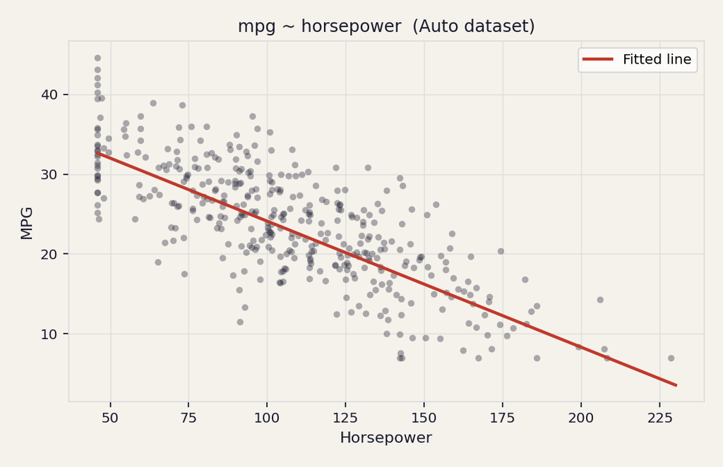

### Show: Homework I — Residual Diagnostics

Evidence · Homework-I.Rmd — Q1c (residuals vs fitted)

Part (c) required checking the linear regression assumptions by plotting residuals against fitted values and examining the Q-Q plot.

[figure not shown]

### Tell: Why this demonstrates the objective

Maximum likelihood estimation underlies OLS when we assume normally distributed errors: the OLS estimates are exactly the MLEs of β under that model. Every p-value I computed flows from this assumption — the t-statistics follow a t-distribution *because of* the normality assumption on ε. When I diagnosed the curved residual pattern and heteroscedasticity in the Boston dataset, I ran a Shapiro-Wilk test and formally rejected the normality assumption, concluding the model should not be used as-is. That willingness to reject the probabilistic foundation when the evidence demands it is, I think, the clearest sign that I understand what probability is doing here — it is not decoration, it is the engine of inference.

Supporting evidence · Homework-I, Q2

In the bias-variance question, I explained why a cubic model has lower *training* RSS but higher expected *test* RSS when the true relationship is linear — reasoning entirely in terms of expectations under a probability model.

Learning Objective 02

## Apply the appropriate generalized linear model for a specific data context

Choosing the right model means matching the model’s assumptions to what the data actually are. This objective is best demonstrated through Project 2, where we faced three distinct outcome types and had to make principled choices for each — including replacing a model that failed its own assumptions.

### Show: Project 2 — Poisson → Negative Binomial

Evidence · project2_classification_k12.Rmd — Section 8

FSFREQ (times parents attended school activities) is a non-negative integer count, making Poisson regression the natural starting point. Before interpreting any results, we checked the core Poisson assumption: variance equals the mean.

Variance (FSFREQ)85.4

Var / Mean12.2×

Poisson deviance ratio5.12

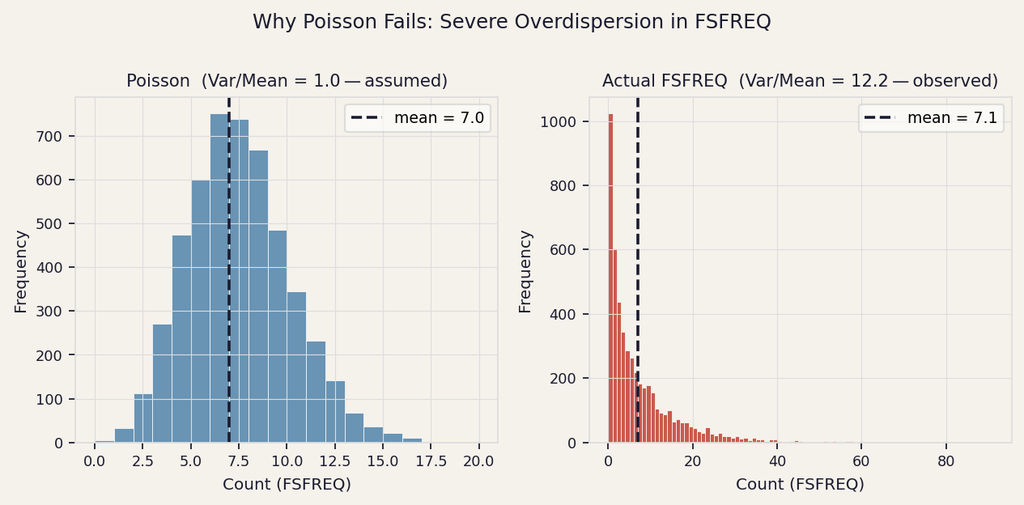

Fig 3 · Why Poisson fails on FSFREQ (Project 2). Left: what Poisson assumes — a symmetric distribution where variance equals the mean (ratio = 1.0). Right: the actual FSFREQ distribution, heavily right-skewed with variance 12.2× larger than the mean. Using Poisson here would severely underestimate standard errors.

```
# Poisson deviance/df = 5.12 >> 1: invalid, standard errors underestimated
# Var/mean ratio from EDA = 12.2: confirms severe overdispersion

# Negative Binomial adds dispersion parameter θ
nb_mod <- poisson_reg() |>
  set_engine("glm.nb") |>
  set_mode("regression")
# LR test NB vs Poisson: statistic=60.3, p<0.001 — NB wins
```

### Show: Homework IV — Multinomial Logistic Regression

Evidence · Homework-IV.Rmd (nonvoters dataset, n=5,836)

Fitting multinomial logistic regression for `voter_category` ∈ {rarely/never, sporadic, always}. I extended the class model by adding party identification, compared the two models, and interpreted coefficients in both log-odds and odds-ratio form.

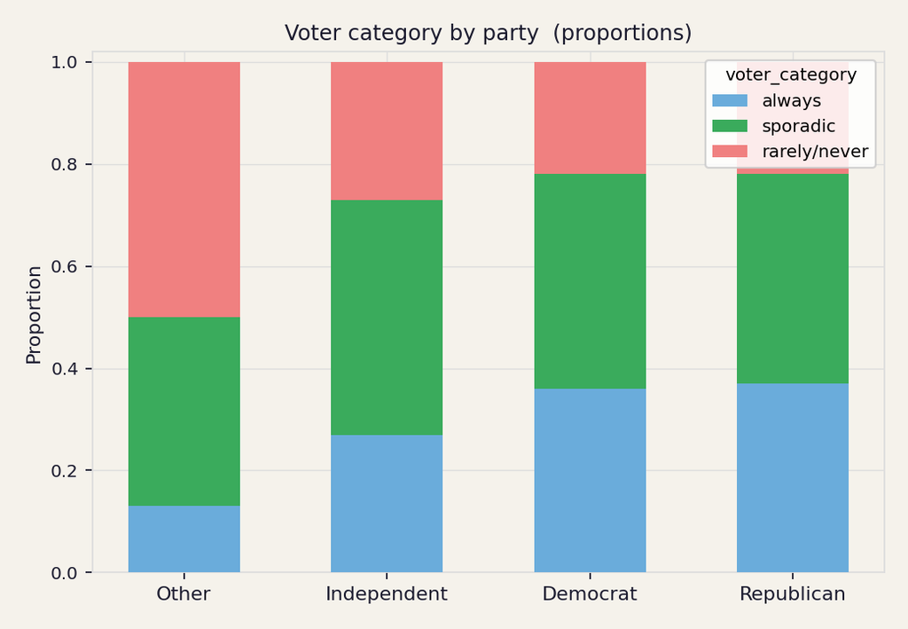

Fig 4 · Voter category by party (HW-IV, `ggbivariate()`). The “Other” group has ~50% rarely/never voters vs. ~22% for Democrats and Republicans — confirming party adds meaningful predictive information beyond demographics alone.

Democrats had 4.06× higher odds of being an “always” voter vs. “rarely/never” compared to “Other” identifiers (β = 1.401). Republicans showed 3.45× higher odds (β = 1.239). Adding party reduced the gender coefficient from −0.211 to −0.192, suggesting some of the gender–voting relationship is mediated by party identity.

### Supporting: Project 2 — LDA as a Theoretically Distinct Approach

We also applied Linear Discriminant Analysis alongside logistic regression. Where logistic regression models P(Y=k|X) directly, LDA models P(X|Y=k) and uses Bayes’ theorem. LDA achieved AUC = 0.651 vs. logistic regression’s 0.743 — a gap that was principled and expected: LDA could not use the categorical predictors (race, parent education, disability) that drove logistic regression’s performance. Comparing the two taught me that “appropriate model” depends on the nature of predictors available, not just the outcome type.

**Key insight:** Choosing the right GLM means diagnosing when your first choice fails its own assumptions (Poisson → NB), and understanding why two valid methods produce different results by design (logistic vs. LDA).

Learning Objective 03

## Demonstrate model selection given a set of candidate models

Model selection is the process of choosing from a set of candidates honestly — not overfitting to the data we happen to have, and not using the same data to both select and evaluate. I have demonstrated this through best-subset selection in Project 1 and manual backward elimination in HW-III.

### Show: Project 1 — Non-linearity as Motivation for Polynomial Terms

Evidence · project1_diamonds_linear_regression.Rmd — Section 2.3 (nonlinear-check chunk)

Before any model selection, we established that the relationship between physical dimension x and carat weight is non-linear. The Rmd code overlays both a linear fit and a LOESS smooth on the scatter of carat vs. x.

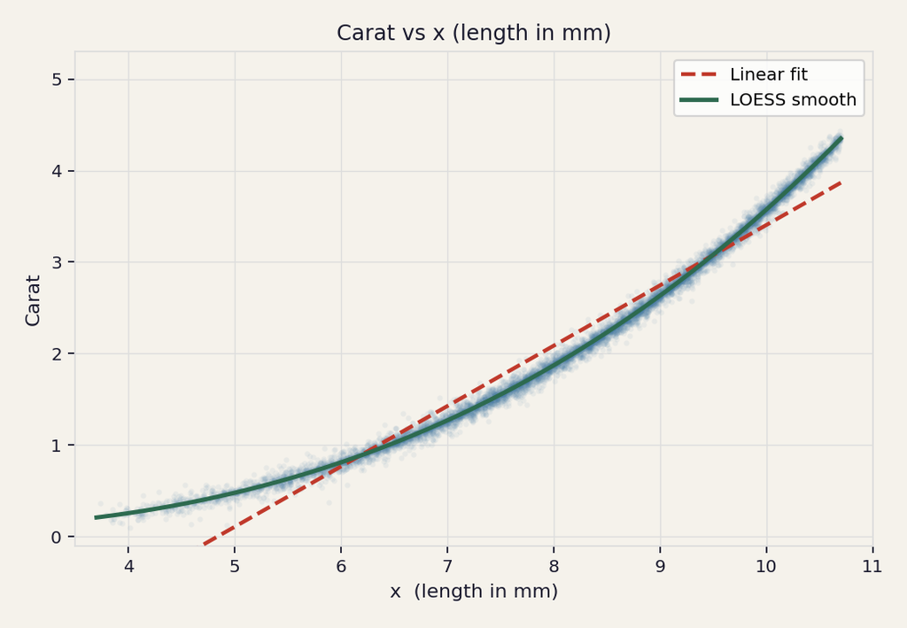

### Show: Project 1 — Best-Subset Selection with Held-Out Validation

Evidence · project1_diamonds_linear_regression.Rmd — Section 4 (validation-set chunk)

With 25 candidate predictors we used exhaustive best-subset selection via `regsubsets()`. The critical methodological decision was to compute validation-set MSE for each model size using a three-way train/validation/test split — the test set was never touched until the very end.

```
# Three-way holdout — data leakage prevention
diamonds_split <- initial_split(diamonds_clean, prop = 0.80)
train_val  <- training(diamonds_split)    # 80%
test_set   <- testing(diamonds_split)     # 20% — never touched until end
val_split  <- initial_split(train_val, prop = 0.80)
train_set  <- training(val_split)          # 64% — model fitting
val_set    <- testing(val_split)           # 16% — model selection
```

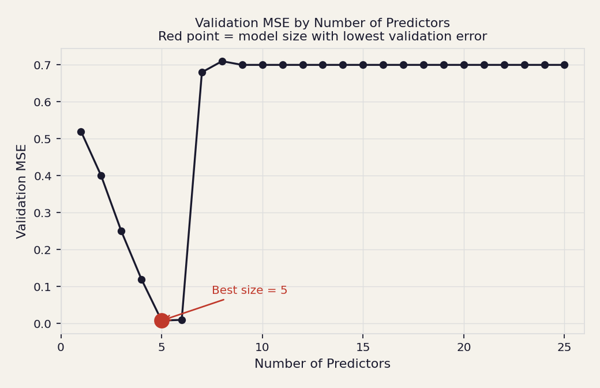

Best model size5 predictors

Test R²0.997

Test RMSE0.026 carats

Excluded by selectionCut, Color, Clarity

### Supporting: Homework III — Manual Backward Elimination

Evidence · Homework-III.Rmd (Auto dataset, backward selection)

Starting from a full model predicting acceleration from all remaining Auto predictors, I manually removed the predictor with the highest p-value at each step, tracking adjusted R² throughout.

| Step | Removed | Adj. R² | Reason |
| --- | --- | --- | --- |
| 1 | — | 0.576 | Full model, 6 predictors |
| 2 | cylinders (p=0.961) | 0.577 | No information beyond displacement |
| 3 | mpg (p=0.289) | 0.577 | Redundant given weight and horsepower |
| 4 | year (p=0.552) | 0.578 | Not significant; final model: test R²=0.722 |

After selection I checked VIF: displacement (9.4) and weight (7.6) exceeded 5, signaling residual multicollinearity. I flagged this explicitly and noted coefficient interpretations require caution — an honest step that is easy to skip.

Learning Objective 04

## Express the results of statistical models to a general audience

Numbers from a model mean nothing until they are explained to someone who did not fit it. This objective is about translating statistical outputs into language a non-statistician can act on.

### Show: Homework II — Interaction Term Motivation and Interpretation

Evidence · Homework-II.Rmd — Interaction exploration (Carseats dataset)

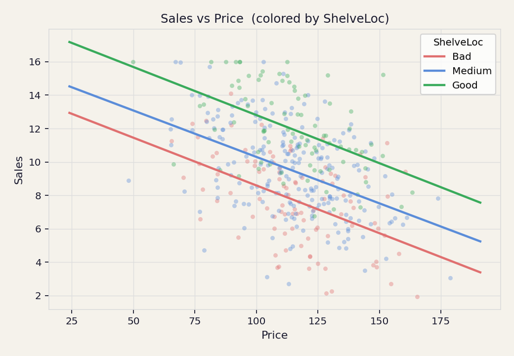

Plain-language interpretation (Homework-II)

“Keeping everything else constant, when carseats are placed on a medium-quality shelf as opposed to a bad shelf, the sales volume decreases by (62 − 6) = 56 units for every $1 increase in price.”

A retailer does not want to know β<sub>1</sub> and β<sub>7</sub> separately — they want to know: if I raise price by $1 on a medium shelf, what happens to sales? Combining main effects and interaction terms into a single actionable sentence is what communication to a general audience requires.

### Show: Project 1 — The Jeweler’s Insight

In the Project 1 report, we translated a test RMSE of 0.026 carats into a tangible implication: *“A jeweler equipped with a millimeter gauge and a table-angle tool could estimate any diamond’s carat weight to within roughly 0.026 carats, without a scale.”* We also made the counterintuitive finding legible: quality grades (cut, color, clarity) — the features most buyers focus on — add no predictive power once physical dimensions are known, because large diamonds are difficult to cut and clarity-grade perfectly.

### Tell: Growth Over the Semester

In HW-I my interpretations were correct but mechanical: *“The relationship is negative as indicated by the negative slope.”* By Project 2, I was writing: *“Racial and ethnic disparities persist after controlling for income and parent education, suggesting structural factors beyond socioeconomic status.”* The habit of pairing every model output with a plain-language sentence has become automatic.

Learning Objective 05

## Use programming software to fit and assess statistical models

TidyModels provides a unified interface for fitting, assessing, and comparing models. This objective is about fluency with that interface — not just running code, but understanding the workflow and making deliberate implementation choices.

### Show: Homework II — Full TidyModels Pipeline

```
# 1. Specification
lm_spec <- linear_reg() |> set_engine("lm") |> set_mode("regression")

# 2. Split + fit with interaction
carseats_split <- initial_split(carseats, prop = 0.80)
model <- lm_spec |> fit(Sales ~ Price * ShelveLoc + Age + Advertising,
                        data = training(carseats_split))

# 3. Assess
tidy(model)    # coefficients, SEs, p-values
glance(model)  # R², adj R², AIC, BIC
augment(model, new_data = testing(carseats_split))

# Test R² = 0.726 vs train R² = 0.675 → generalises well
```

### Show: Homework III — Reusable Function

```
# Encapsulate the repetitive step-reporting pattern
report_step <- function(model, step_title = "Step 1", alpha = 0.05) {
  td <- tidy(model)
  gl <- glance(model)
  candidates <- td |>
    filter(term != "(Intercept)", p.value > alpha) |>
    arrange(desc(p.value))
  print(step_title); print(td); print(gl); print(candidates)
}
```

### Show: Project 2 — Advanced TidyModels

Project 2 pushed our software use into more advanced territory. To address the 31:1 class imbalance in grade categories, we used `step_upsample()` from the {themis} package — applied only within training folds so the test set remained in its natural distribution. We also applied `repair_call()`, a TidyModels utility that fixes an internal reference bug preventing `augment()` from working on fitted multinomial models.

For model validation we used 10-fold cross-validation via `vfold_cv()` and `fit_resamples()`. The CV AUC of 0.726 closely tracking the test AUC of 0.743 confirmed that the held-out result was not a lucky split. Everything was bundled into `workflow()` objects that combine the recipe preprocessing steps with the model specification, keeping the pipeline auditable and preventing any data leakage between folds.

**Reflection:** My background as an ML engineer meant I was comfortable with Python and sklearn. Learning TidyModels taught me a different philosophy — where each step is explicit and auditable. I now apply this pipeline thinking back in my ML work.

Course Community

## Participation in our course learning community

Participation means active contribution to a shared intellectual community — not just showing up or submitting work.

#### Questions in class

I made a deliberate habit of asking questions during class. When we covered multinomial logistic regression, I asked about interpretation when the baseline category changes — opening a useful discussion about reference level choices.

#### Team contributions

In Project 2, I led the Poisson overdispersion diagnosis and the move to Negative Binomial. In Project 1, I wrote the Diagnostics and Conclusion sections of the report.

#### Peer collaboration

Working with Kabin, Shreya, and Udita across two projects meant negotiating modeling choices. The upsampling decision in Project 2 came from a team discussion where I initially preferred sample weights.

#### Acting on feedback

Feedback on HW-I about assumption checking shaped how I approached diagnostics in HW-II and HW-III — spending more time interpreting what residual patterns mean for the validity of inference.

I will be honest about where I fell short: my goal of maximizing in-class engagement while balancing multiple responsibilities was the hardest to achieve consistently. There were weeks, particularly in March, where competing research and internship deadlines meant I came to class less prepared than I wanted. Preparation is a prerequisite for active participation, not a nice-to-have.

Self-Evaluation

## Letter of Self-Evaluation

My self-evaluation letter responds directly to the Letter of Commitment I wrote in January, evaluating my three learning goals and overall progress in the course.

Read the Self-Evaluation Letter →

Source Files

## References & Downloads

Source files for all homeworks and projects are available below. Upload them to the `assets/` folder of the repository to activate the links.

### Projects

Project 1 — Linear Regression (Diamonds)

Can carat weight be predicted from visual characteristics? Best-subset selection, polynomial regression, three-way validation split. Test R² = 0.997.

Report PDF Source Rmd

Project 2 — Classification (K-12 Education)

Predicting educational success from family engagement. Multinomial logistic regression, Negative Binomial, logistic regression, LDA/QDA on the 2019 PFI survey.

Report Docx Source Rmd

### Homeworks

Homework I — Simple Linear Regression

Auto and Boston datasets. Simple linear regression, confidence vs. prediction intervals, residual diagnostics, Shapiro-Wilk normality test.

PDF HTML Source Rmd

Homework II — Multiple Regression

Carseats dataset. Multiple regression with a Price × ShelveLoc interaction term, train/test evaluation, and assumption diagnostics.

PDF HTML Source Rmd

Homework III — Backward Selection

Auto dataset. Manual p-value-based backward elimination predicting acceleration. Reusable `report_step()` function, VIF/multicollinearity analysis.

PDF HTML Source Rmd

Homework IV — Multinomial Logistic Regression

FiveThirtyEight nonvoters survey (n=5,836). Multinomial logistic regression for voter category. Model comparison with and without party affiliation, odds ratio interpretation.

PDF HTML Source Rmd